# Stacked Ensembles with Tidymodels

2024-06-05

# Stacking

Stacking is a very powerful approach to improving predictive performance. This notebook introduces the `stacks` package in the `tidymodels` for predicting household wealth. It borrows heavily from this resource: https://stacks.tidymodels.org/articles/basics.html

## Get started

First load necessary libraries (or install if don’t yet have) and the data.

## Procedure set-up

We will train the data using cross-validation (set at 5 folds).

```r
set.seed(1) # for reproducibility
df_split <- initial_split(df) # default is 75% training
df_train <- training(df_split)
df_test  <- testing(df_split)

set.seed(1)
folds <- rsample::vfold_cv(df_train, v = 5)
```

We then set the model formula (net wealth as a function of all variables) and performance metric (root mean squared error). We also set appropriate defaults settings for the stack (e.g. storing predictions from each fold) using `control_stack_*` functions.

```r
# define 'recipe'
df_rec <- recipe(net_wealth ~ ., data = df_train)

# extend the recipe
df_rec <- df_rec %>%
  step_dummy(all_nominal_predictors()) %>%
  step_zv(all_predictors()) %>% # in case some variables have do not actually vary
  step_normalize(all_numeric_predictors())

# you can do other pre-processing in the recipe here, for example: step_impute_mean(all_numeric_predictors())


metric <- metric_set(rmse)

ctrl_grid <- control_stack_grid()
ctrl_res <- control_stack_resamples()
```

## Fitting level 1 (or candidate) models

Now let’s start training some modesls! There is a list of all models available for us in `tidymodels` here: https://www.tidymodels.org/find/parsnip/

We’ll start with some classics: linear regression, a random forest, and a simple neural network.

```r
# create a model definition
lin_reg_spec <- linear_reg() %>%
  set_engine("lm")

# add both to a workflow
lin_reg_wflow <- workflow() %>%
  add_model(lin_reg_spec) %>%
  add_recipe(df_rec)

# fit to the 5-fold cv
set.seed(2020)
lin_reg_res <- fit_resamples(
    lin_reg_wflow,
    resamples = folds,
    metrics = metric,
    control = ctrl_res
  )

lin_reg_res
```

```
## # Resampling results
## # 5-fold cross-validation
## # A tibble: 5 × 5
##   splits               id    .metrics         .notes           .predictions
##   <list>               <chr> <list>           <list>           <list>
## 1 <split [10579/2645]> Fold1 <tibble [1 × 4]> <tibble [0 × 3]> <tibble>
## 2 <split [10579/2645]> Fold2 <tibble [1 × 4]> <tibble [0 × 3]> <tibble>
## 3 <split [10579/2645]> Fold3 <tibble [1 × 4]> <tibble [0 × 3]> <tibble>
## 4 <split [10579/2645]> Fold4 <tibble [1 × 4]> <tibble [0 × 3]> <tibble>
## 5 <split [10580/2644]> Fold5 <tibble [1 × 4]> <tibble [0 × 3]> <tibble>
```

Now let’s fit the random forest (which is itself an ensemble and will take a bit longer).

```r
# create a model definition
rf_spec <- rand_forest(
  mode = "regression"
  ) %>%
  set_engine("ranger")

# add to workflow
rf_wflow <- workflow() %>%
  add_model(rf_spec) %>%
  add_recipe(df_rec)

# fit to the 5-fold cv
set.seed(2020)
rf_res <- fit_resamples(
    rf_wflow,
    resamples = folds,
    metrics = metric,
    control = ctrl_res
  )
```

And finally, the neural network

```r
# create a model definition
nn_spec <- mlp(
  mode = "regression"
  ) %>%
  set_engine("nnet")

# add both to a workflow
nn_wflow <- workflow() %>%
  add_model(nn_spec) %>%
  add_recipe(df_rec)

# fit to the 5-fold cv
set.seed(2020)
nn_res <- fit_resamples(
    nn_wflow,
    resamples = folds,
    metrics = metric,
    control = ctrl_res
  )
```

## Add you own

Choose one or more models to add as candidates: https://www.tidymodels.org/find/parsnip/

```r
# your code here
```

## Stacking time!

First, we add the ‘candidates’ (level 1 models) together. Include additional `add_candidates()` if you have fit more models above.

```r
df_data_st <- stacks() %>%
  add_candidates(lin_reg_res) %>%
  add_candidates(rf_res) %>%
  add_candidates(nn_res)

as_tibble(df_data_st)
```

```
## # A tibble: 13,224 × 4
##    net_wealth lin_reg_res_1_1 rf_res_1_1 nn_res_1_1
##         <dbl>           <dbl>      <dbl>      <dbl>
##  1      16.2            15.9     15.7         15.7
##  2      15.7            15.6     15.5         15.4
##  3     -10.5             4.34     0.0385       5.24
##  4      11.6            11.6     12.1         10.5
##  5      13.3            14.2     13.2         14.3
##  6       5.00            4.63     1.67         2.55
##  7      14.6            12.7     15.6         14.9
##  8       8.53            5.86     5.86         6.39
##  9      11.6            10.9      8.02        10.5
## 10      15.0            14.4     13.0         12.5
## # ℹ 13,214 more rows
```

Now we ‘blend’ the predictions (fit a second level model in other words).

The default in stacks is to use a LASSO model, which can reduce coefficients (or model weights) to 0. You can change this behaviour using the `penalty` or `mixture` arguments. Setting `penalty = 0` will implement a standard linear regression.

Check the documentation for `blend_predictions()`: https://stacks.tidymodels.org/reference/blend_predictions.html

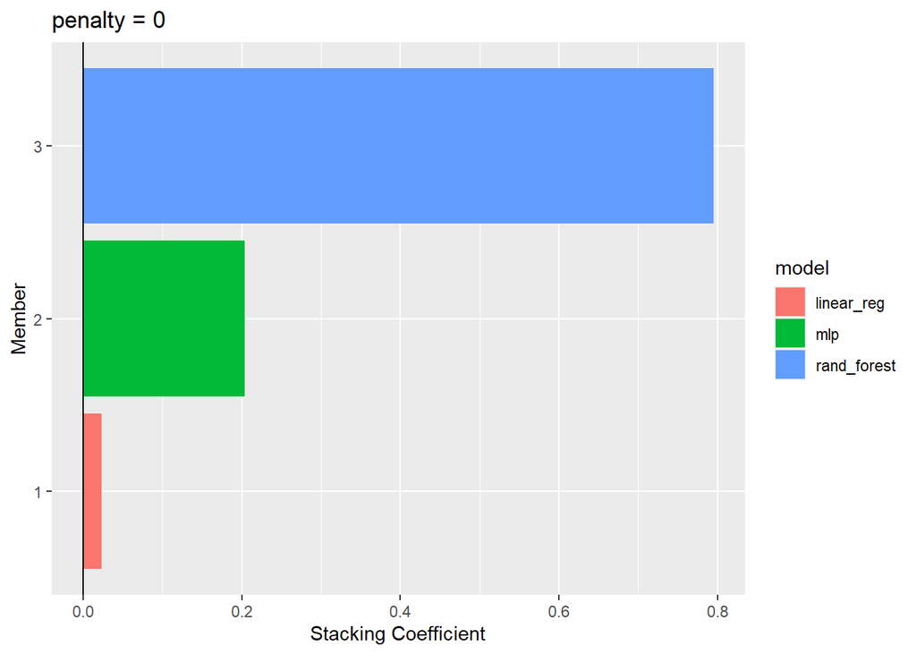

```r
#' (LASSO second-level model)
df_model_st <-
  df_data_st %>%
  blend_predictions(penalty = 0)

# see weights
autoplot(df_model_st, type = "weights")
```

Now we can fit the stack. We do this in the code chunk below and then also use our fitted stack to make predictions on the hold-out test set.

```r
# fit stack
df_model_st <- df_model_st %>%
  fit_members()

# predict on test set
df_test <- df_test %>%
  bind_cols(predict(df_model_st, .))
```

## Evaluate stack performance

Now we are ready to examine how well our stack has done relative to the individual level one models.

```r
# examine performance
df_test <- df_test %>%
  bind_cols(predict(df_model_st, .))

# compare stack w individual members
member_preds <- df_test %>%
  select(net_wealth) %>%
  bind_cols(predict(df_model_st, df_test, members = TRUE))

# check RMSE
map(member_preds, rmse_vec, truth = member_preds$net_wealth) %>%
  as_tibble()
```

```
## # A tibble: 1 × 5
##   net_wealth .pred lin_reg_res_1_1 rf_res_1_1 nn_res_1_1
##        <dbl> <dbl>           <dbl>      <dbl>      <dbl>
## 1          0  4.97            5.16       4.99       5.03
```